# Economy in the World

Yiğit Alp Yalçın

20 06 2021

# Team Member

-*Yiğit Alp Yalçın*

# Topic

The topic is Economy in the world with every aspects of it. Economy is been a issue by a long time. It can change every year,month or even in second dramatically.That effects human life standard. In order to see these affects on human life it will be examined to understand which attributes of economy are significant for the humanity.

# About the Plan

First step is understanding the problem and the data and try to find a proper route for it.Than it will be extract into R. After the extraction it will be examined by the class of columns and the missing datas in the set. After cleaning complete visualization will start. Line,histogram and many more will be used in the data for visualization. After the visualization it will be more clear to see every aspect. Finally with whole data we have, It will be merged with a geometry map data set to get a world map at the end of it.

# Final Product

As final product, I here tried to show the difference between whole countries in the world by economically with other attributes also.In each graph there have been used different attributes comparison. Finally it will be mapped in order to see clearly difference by region or by countries.

```r
View(Alldata)
```

```r
colnames(Alldata)
```

```
##  [1] "Name"                   "Index Year"             "Overall Score"
##  [4] "Property Rights"        "Government Integrity"   "Judicial Effectiveness"
##  [7] "Tax Burden"             "Government Spending"    "Fiscal Health"
## [10] "Business Freedom"       "Labor Freedom"          "Monetary Freedom"
## [13] "Trade Freedom"          "Investment Freedom"     "Financial Freedom"
```

```r
dim(Alldata)
```

```
## [1] 4053   15
```

```r
names(Alldata)[1]<-paste("Country")
names(Alldata)[2]<-paste("Year")
names(Alldata)[3]<-paste("Overall.score")
names(Alldata)[4]<-paste("Property.rights")
names(Alldata)[5]<-paste("Goverment.integrity")
names(Alldata)[6]<-paste("Judicial.effect")
names(Alldata)[7]<-paste("Tax.burden")
names(Alldata)[8]<-paste("Goverment.spending")
names(Alldata)[9]<-paste("Fiscal.health")
names(Alldata)[10]<-paste("Business.freedom")
names(Alldata)[11]<-paste("Labor.freedom")
names(Alldata)[12]<-paste("Monetary.freedom")
names(Alldata)[13]<-paste("Trade.freedom")
names(Alldata)[14]<-paste("Investment.freedom")
names(Alldata)[15]<-paste("Financial.freedom")
View(Alldata)
```

```r
str(Alldata)
```

```
## spec_tbl_df [4,053 x 15] (S3: spec_tbl_df/tbl_df/tbl/data.frame)
##  $ Country            : chr [1:4053] "Afghanistan" "Albania" "Algeria" "Angola" ...
##  $ Year               : num [1:4053] 2021 2021 2021 2021 2021 ...
##  $ Overall.score      : num [1:4053] 53 65.2 49.7 54.2 52.7 71.9 82.4 73.9 70.1 69.9 ...
##  $ Property.rights    : num [1:4053] 30.3 46.1 34 30.3 46.1 57.3 81.5 86.8 67.9 71.5 ...
##  $ Goverment.integrity: num [1:4053] 29.1 40.6 32.7 20.4 54 45 89.8 84.8 46.8 64.4 ...
##  $ Judicial.effect    : num [1:4053] 25.7 22.8 41.6 22.8 45.7 55.3 90 83.5 55.8 65.8 ...
##  $ Tax.burden         : num [1:4053] 91.1 89 67.2 87.3 70.4 87.1 62.6 45.7 88.1 100 ...
##  $ Goverment.spending : num [1:4053] 76.1 74.6 55.4 86.9 52.8 81.3 58.1 29.1 65.2 67.1 ...
##  $ Fiscal.health      : num [1:4053] 99.9 86.6 49.1 77.9 38.4 84.3 88.7 90 99.4 0 ...
##  $ Business.freedom   : num [1:4053] 53.9 66.1 63.5 56.9 59.5 81.9 87.4 72.6 80.5 76.7 ...
##  $ Labor.freedom      : num [1:4053] 59.9 51.6 51.3 59.6 46.3 74.5 84.1 68.4 65.9 71.4 ...
##  $ Monetary.freedom   : num [1:4053] 80.8 82 84.3 67.5 41.9 76.9 86.7 81.7 73.2 82.8 ...
##  $ Trade.freedom      : num [1:4053] 68.6 82.8 57.4 70.2 62.6 73.8 89.8 84 68 83.6 ...
##  $ Investment.freedom : num [1:4053] 10 70 30 30 55 75 80 90 70 75 ...
##  $ Financial.freedom  : num [1:4053] 10 70 30 40 60 70 90 70 60 80 ...
##  - attr(*, "spec")=
##   .. cols(
##   ..   Name = col_character(),
##   ..   `Index Year` = col_double(),
##   ..   `Overall Score` = col_character(),
##   ..   `Property Rights` = col_character(),
##   ..   `Government Integrity` = col_character(),
##   ..   `Judicial Effectiveness` = col_character(),
##   ..   `Tax Burden` = col_character(),
##   ..   `Government Spending` = col_character(),
##   ..   `Fiscal Health` = col_character(),
##   ..   `Business Freedom` = col_character(),
##   ..   `Labor Freedom` = col_character(),
##   ..   `Monetary Freedom` = col_character(),
##   ..   `Trade Freedom` = col_character(),
##   ..   `Investment Freedom` = col_character(),
##   ..   `Financial Freedom` = col_character()
##   .. )
```

```r
summary(Alldata)
```

```
##    Country               Year      Overall.score   Property.rights
##  Length:4053        Min.   :2000   Min.   : 1.00   Min.   : 0.00
##  Class :character   1st Qu.:2005   1st Qu.:53.30   1st Qu.:30.00
##  Mode  :character   Median :2011   Median :59.80   Median :45.35
##                     Mean   :2011   Mean   :60.04   Mean   :47.49
##                     3rd Qu.:2016   3rd Qu.:67.60   3rd Qu.:65.90
##                     Max.   :2021   Max.   :90.20   Max.   :98.40
##                                    NA's   :318     NA's   :281
##  Goverment.integrity Judicial.effect   Tax.burden     Goverment.spending
##  Min.   :  0.00      Min.   : 5.00   Min.   :  0.00   Min.   : 0.00
##  1st Qu.: 26.00      1st Qu.:30.60   1st Qu.: 67.50   1st Qu.:51.50
##  Median : 34.50      Median :43.25   Median : 76.90   Median :70.60
##  Mean   : 41.06      Mean   :45.44   Mean   : 74.91   Mean   :64.81
##  3rd Qu.: 52.00      3rd Qu.:58.40   3rd Qu.: 84.10   3rd Qu.:83.70
##  Max.   :100.00      Max.   :93.80   Max.   :100.00   Max.   :99.30
##  NA's   :265         NA's   :3131    NA's   :302      NA's   :286
##  Fiscal.health    Business.freedom Labor.freedom    Monetary.freedom
##  Min.   :  0.00   Min.   :  0.00   Min.   :  0.00   Min.   : 0.00
##  1st Qu.: 51.80   1st Qu.: 55.00   1st Qu.: 49.80   1st Qu.:71.00
##  Median : 79.90   Median : 64.30   Median : 60.40   Median :76.90
##  Mean   : 67.96   Mean   : 63.76   Mean   : 60.51   Mean   :74.68
##  3rd Qu.: 92.80   3rd Qu.: 73.70   3rd Qu.: 71.90   3rd Qu.:81.40
##  Max.   :100.00   Max.   :100.00   Max.   :100.00   Max.   :95.40
##  NA's   :3138     NA's   :269      NA's   :1057     NA's   :280
##  Trade.freedom   Investment.freedom Financial.freedom
##  Min.   : 0.00   Min.   : 0.00      Min.   : 0.00
##  1st Qu.:63.60   1st Qu.:35.00      1st Qu.:30.00
##  Median :73.60   Median :50.00      Median :50.00
##  Mean   :71.43   Mean   :53.25      Mean   :49.65
##  3rd Qu.:82.10   3rd Qu.:70.00      3rd Qu.:70.00
##  Max.   :95.00   Max.   :95.00      Max.   :90.00
##  NA's   :295     NA's   :280        NA's   :302
```

```r
alldata2<-Alldata
```

```r
Alldatafrom2018<-  Alldata %>%
  filter(Year>2017)
View(Alldatafrom2018)
```

```r
summary(Alldatafrom2018)
```

```
##    Country               Year      Overall.score   Property.rights
##  Length:742         Min.   :2018   Min.   : 4.20   Min.   : 5.20
##  Class :character   1st Qu.:2018   1st Qu.:54.52   1st Qu.:38.73
##  Mode  :character   Median :2019   Median :61.40   Median :52.40
##                     Mean   :2019   Mean   :61.25   Mean   :53.52
##                     3rd Qu.:2020   3rd Qu.:68.58   3rd Qu.:67.45
##                     Max.   :2021   Max.   :90.20   Max.   :98.40
##                                    NA's   :24      NA's   :4
##  Goverment.integrity Judicial.effect   Tax.burden     Goverment.spending
##  Min.   : 7.50       Min.   : 5.00   Min.   :  0.00   Min.   : 0.00
##  1st Qu.:28.32       1st Qu.:31.07   1st Qu.: 70.65   1st Qu.:53.35
##  Median :37.90       Median :43.85   Median : 78.60   Median :70.30
##  Mean   :43.15       Mean   :45.69   Mean   : 77.24   Mean   :65.21
##  3rd Qu.:51.17       3rd Qu.:58.08   3rd Qu.: 85.80   3rd Qu.:83.85
##  Max.   :97.20       Max.   :93.80   Max.   :100.00   Max.   :96.60
##  NA's   :4           NA's   :4       NA's   :23       NA's   :12
##  Fiscal.health    Business.freedom Labor.freedom   Monetary.freedom
##  Min.   :  0.00   Min.   : 5.00    Min.   : 5.00   Min.   : 0.00
##  1st Qu.: 53.02   1st Qu.:54.70    1st Qu.:50.30   1st Qu.:71.80
##  Median : 80.00   Median :64.00    Median :59.90   Median :77.40
##  Mean   : 68.39   Mean   :63.69    Mean   :59.30   Mean   :75.11
##  3rd Qu.: 92.90   3rd Qu.:75.00    3rd Qu.:68.78   3rd Qu.:81.70
##  Max.   :100.00   Max.   :96.40    Max.   :92.60   Max.   :91.60
##  NA's   :12       NA's   :5        NA's   :8       NA's   :8
##  Trade.freedom   Investment.freedom Financial.freedom
##  Min.   : 0.00   Min.   : 0.00      Min.   : 0.00
##  1st Qu.:66.00   1st Qu.:45.00      1st Qu.:30.00
##  Median :75.60   Median :60.00      Median :50.00
##  Mean   :73.68   Mean   :57.04      Mean   :48.75
##  3rd Qu.:84.00   3rd Qu.:75.00      3rd Qu.:60.00
##  Max.   :95.00   Max.   :95.00      Max.   :90.00
##  NA's   :15      NA's   :9          NA's   :20
```

```r
Alldatafrom2018<-drop_na(Alldatafrom2018)
View(Alldatafrom2018)
summary(Alldatafrom2018)
```

```
##    Country               Year      Overall.score   Property.rights
##  Length:718         Min.   :2018   Min.   : 4.20   Min.   : 5.20
##  Class :character   1st Qu.:2018   1st Qu.:54.52   1st Qu.:39.70
##  Mode  :character   Median :2019   Median :61.40   Median :53.30
##                     Mean   :2019   Mean   :61.25   Mean   :54.21
##                     3rd Qu.:2020   3rd Qu.:68.58   3rd Qu.:67.90
##                     Max.   :2021   Max.   :90.20   Max.   :98.40
##  Goverment.integrity Judicial.effect   Tax.burden     Goverment.spending
##  Min.   : 7.50       Min.   : 5.00   Min.   :  0.00   Min.   : 0.00
##  1st Qu.:29.43       1st Qu.:32.02   1st Qu.: 70.62   1st Qu.:53.62
##  Median :38.20       Median :44.65   Median : 78.55   Median :70.45
##  Mean   :43.82       Mean   :46.40   Mean   : 77.22   Mean   :65.49
##  3rd Qu.:51.50       3rd Qu.:58.85   3rd Qu.: 85.78   3rd Qu.:83.90
##  Max.   :97.20       Max.   :93.80   Max.   :100.00   Max.   :96.60
##  Fiscal.health    Business.freedom Labor.freedom   Monetary.freedom
##  Min.   :  0.00   Min.   : 5.00    Min.   : 5.00   Min.   : 0.00
##  1st Qu.: 53.92   1st Qu.:55.12    1st Qu.:50.30   1st Qu.:72.20
##  Median : 80.45   Median :65.15    Median :60.05   Median :77.50
##  Mean   : 68.99   Mean   :64.13    Mean   :59.43   Mean   :75.42
##  3rd Qu.: 92.90   3rd Qu.:75.20    3rd Qu.:69.20   3rd Qu.:81.90
##  Max.   :100.00   Max.   :96.40    Max.   :92.60   Max.   :91.60
##  Trade.freedom  Investment.freedom Financial.freedom
##  Min.   : 0.0   Min.   : 0.00      Min.   : 0.00
##  1st Qu.:66.2   1st Qu.:45.00      1st Qu.:30.00
##  Median :75.8   Median :60.00      Median :50.00
##  Mean   :73.8   Mean   :57.52      Mean   :48.58
##  3rd Qu.:84.0   3rd Qu.:75.00      3rd Qu.:60.00
##  Max.   :95.0   Max.   :95.00      Max.   :90.00
```

```r
Alldata<-Alldata[-c(6,9,11)]
View(Alldata)
```

```r
Alldata=na.omit(Alldata)
View(Alldata)
summary(Alldata)
```

```
##    Country               Year      Overall.score   Property.rights
##  Length:3735        Min.   :2000   Min.   : 1.00   Min.   : 0.00
##  Class :character   1st Qu.:2005   1st Qu.:53.30   1st Qu.:30.00
##  Mode  :character   Median :2011   Median :59.80   Median :46.40
##                     Mean   :2011   Mean   :60.04   Mean   :47.72
##                     3rd Qu.:2016   3rd Qu.:67.60   3rd Qu.:66.70
##                     Max.   :2021   Max.   :90.20   Max.   :98.40
##  Goverment.integrity   Tax.burden     Goverment.spending Business.freedom
##  Min.   :  0.00      Min.   :  0.00   Min.   : 0.00      Min.   :  0.00
##  1st Qu.: 26.00      1st Qu.: 67.50   1st Qu.:51.80      1st Qu.: 55.00
##  Median : 35.00      Median : 76.80   Median :70.60      Median : 64.80
##  Mean   : 41.39      Mean   : 74.84   Mean   :64.89      Mean   : 63.88
##  3rd Qu.: 52.00      3rd Qu.: 84.00   3rd Qu.:83.70      3rd Qu.: 73.80
##  Max.   :100.00      Max.   :100.00   Max.   :99.30      Max.   :100.00
##  Monetary.freedom Trade.freedom   Investment.freedom Financial.freedom
##  Min.   : 0.00    Min.   : 0.00   Min.   : 0.00      Min.   : 0.00
##  1st Qu.:71.10    1st Qu.:63.80   1st Qu.:40.00      1st Qu.:30.00
##  Median :77.00    Median :73.70   Median :50.00      Median :50.00
##  Mean   :74.78    Mean   :71.43   Mean   :53.42      Mean   :49.63
##  3rd Qu.:81.50    3rd Qu.:82.10   3rd Qu.:70.00      3rd Qu.:60.00
##  Max.   :95.40    Max.   :95.00   Max.   :95.00      Max.   :90.00
```

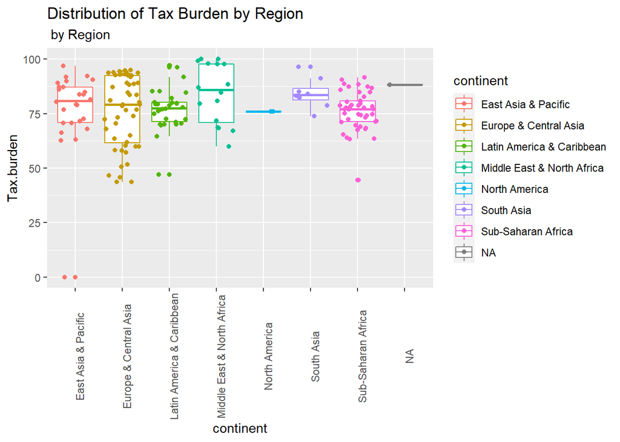

```r
Alldata %>%
  filter(Year==2021) %>%
  ggplot(aes(continent, Tax.burden, color=continent)) +  geom_boxplot() +        geom_jitter()+
  ggtitle("Distribution of Tax Burden by Region", subtitle = " by Region")+
  theme(axis.text.x = element_text(angle = 90))
```

```r
library(DT)
top_rankdt <- Alldata[c(1,2,5)] %>%
  filter(Year==2021)
datatable(head(top_rankdt, 50), class = 'cell-border stripe', caption = 'Highest Goverment Integrity to Lowest at 2021', options = list(
order = list(list(3, 'desc'))))
```

[output not shown]

[output cut: 40 more lines]

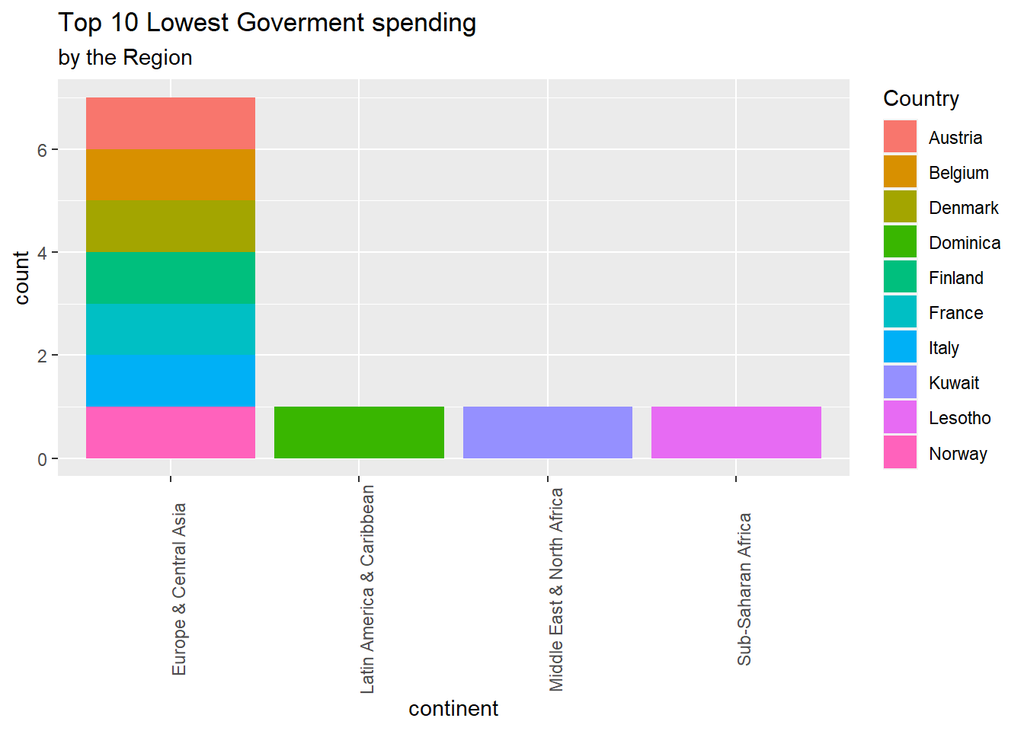

```r
Alldata %>%
  filter(Year==2021 & Goverment.spending <29.2 & Goverment.spending> 6 ) %>%
  ggplot(aes(continent, fill=Country)) +  geom_bar() +
  ggtitle("Top 10 Lowest Goverment spending", subtitle = "by the Region")+
   theme(axis.text.x = element_text(angle = 90))
```

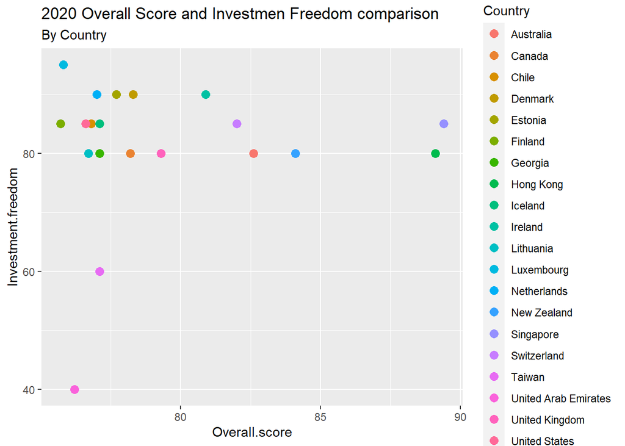

```r
Alldata%>%
  filter(Year==2020 & Overall.score>75 ) %>%
  ggplot(aes(x=Overall.score, y=Investment.freedom, color=Country)) +
  geom_point(size=3) +
  ggtitle("2020 Overall Score and Investmen Freedom comparison ",
          subtitle = "By Country")
```